# Лабораторная работа №11

Текстовой редактор emacs

Липатников Андрей

1032253853@rudn.ru

Российский университет дружбы народов

2026-10-08

# Информация

## Докладчик

- Липатников Андрей
- Студент НКАбд-04-25
- Российский университет дружбы народов
- 1032253853@rudn.ru

# Вводная часть

## Актуальность

- Emacs установлен во всех основных дистрибутивах Linux
- используется как редактор и как среда разработки
- встроенные режимы поддерживают C, Python, Perl, Lisp
- навык применим в администрировании и разработке

## Объект и предмет исследования

- **Объект**: текстовой редактор Emacs
- **Предмет**: команды Emacs, работа с буферами, окнами и поиском

## Цели и задачи

- **Цель**: познакомиться с Linux; получить практические навыки работы с редактором Emacs.
- **Задачи**:
- изучить термины Emacs (буфер, фрейм, окно, минибуфер)
- освоить создание и сохранение файла
- освоить работу с текстом
- освоить управление буферами и окнами
- освоить режим поиска и замены

## Материалы и методы

# Содержание исследования

## Термины Emacs

- **Буфер** — объект, содержащий текст (файл, справка, компиляция)
- **Фрейм** — окно в обычном понимании
- **Окно** — прямоугольная область фрейма, отображающая буфер
- **Минибуфер** — область ввода дополнительной информации
- **Точка вставки** — место вставки/удаления данных

## Запуск Emacs и создание файла

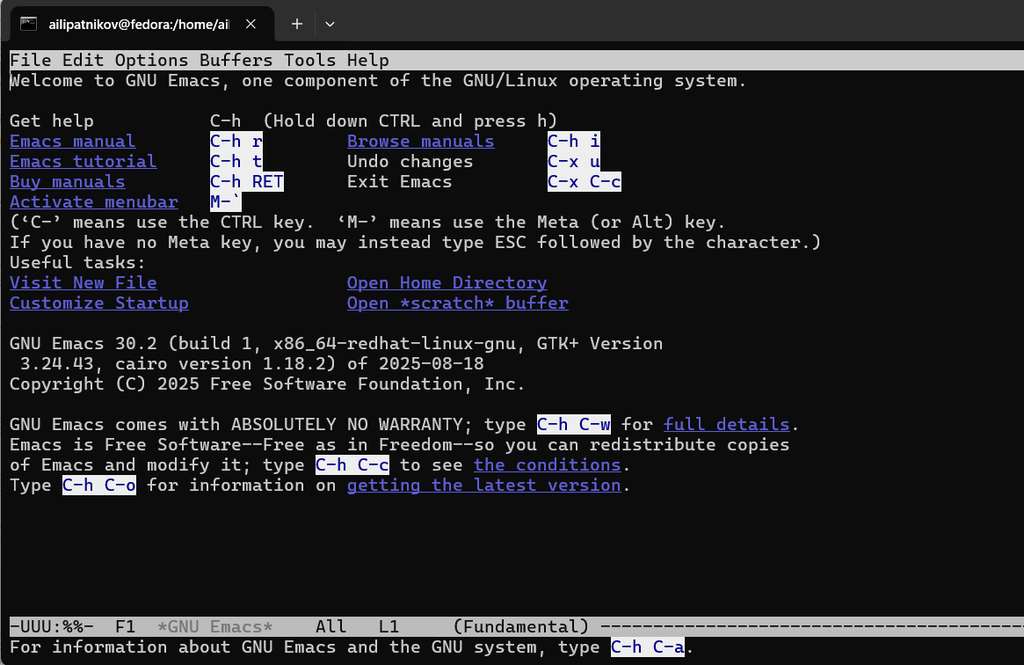

Стартовый экран Emacs

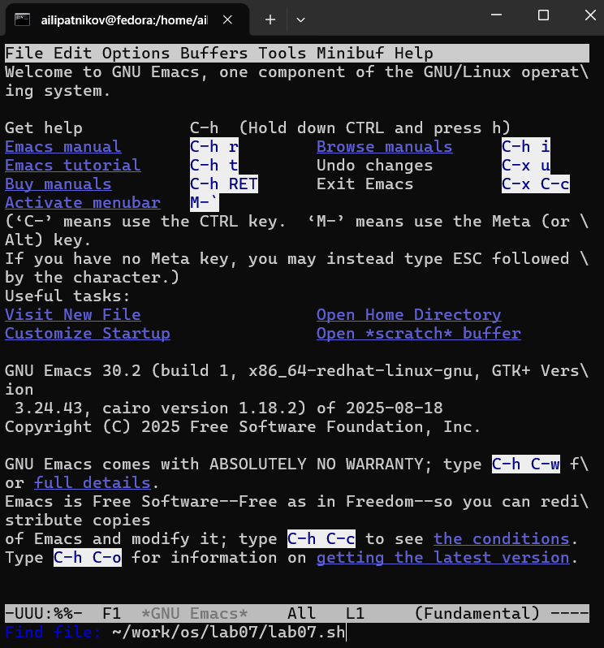

Создание файла C-x C-f

- `C-x C-f` — открыть файл; минибуфер: `~/work/os/lab07/lab07.sh`

## Ввод и сохранение текста

- введён текст скрипта (шебанг, функция hello, вызов hello)
- `C-x C-s` — сохранение

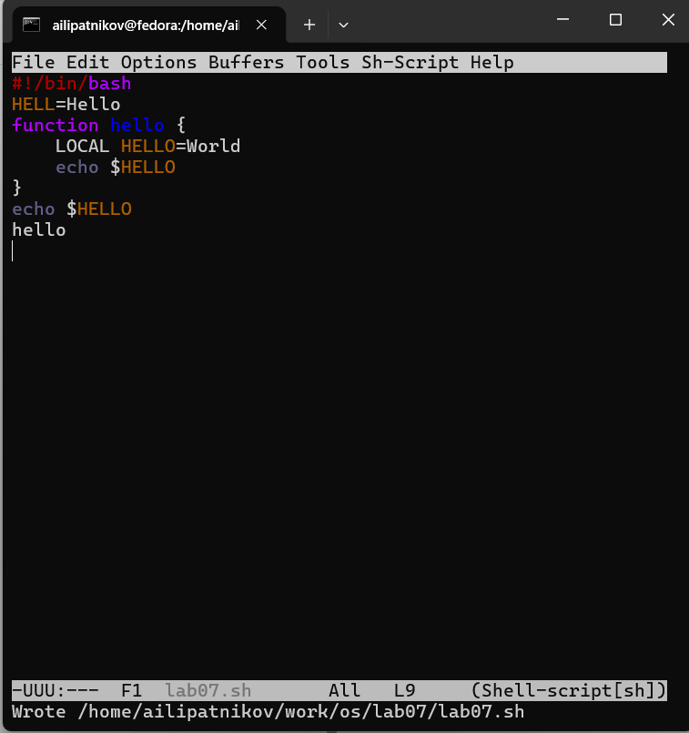

Ввод текста и сохранение lab07.sh

## Навигация и переход в конец строки

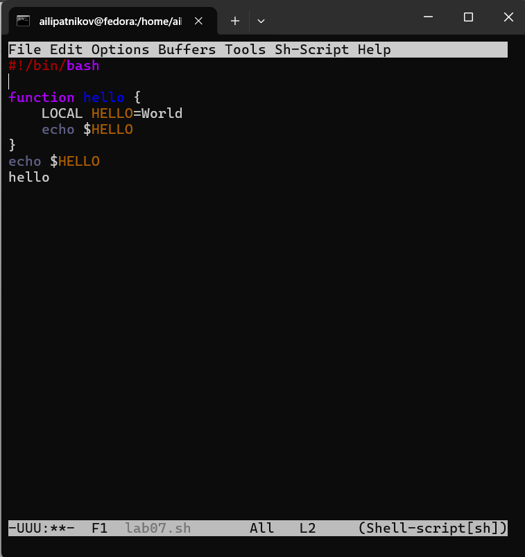

Переход в начало буфера M-<

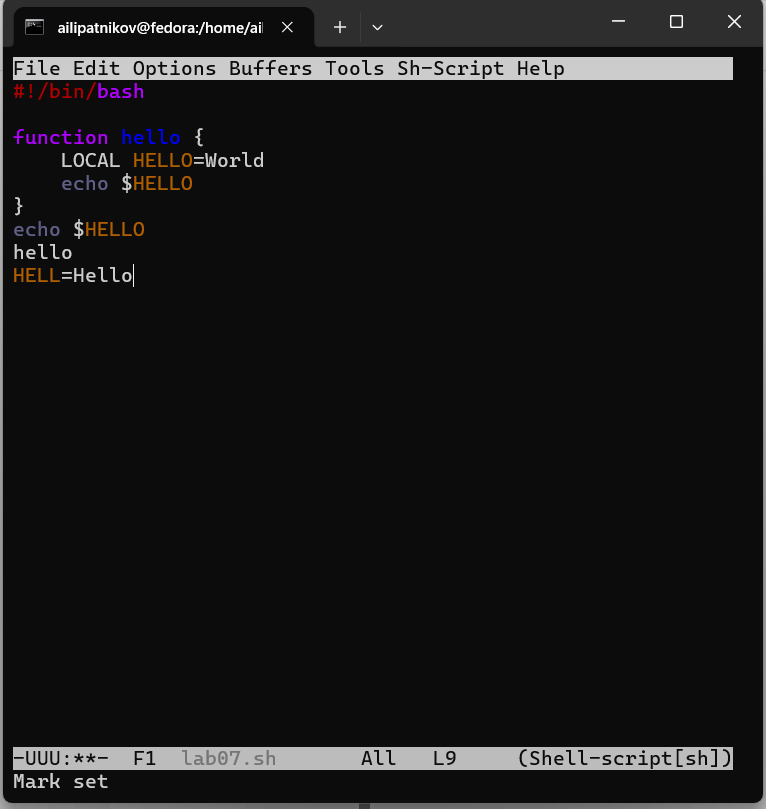

Переход в конец строки C-e

- `M-<` — начало буфера; `C-e` — конец строки

## Работа с текстом: выделение, копирование, вставка

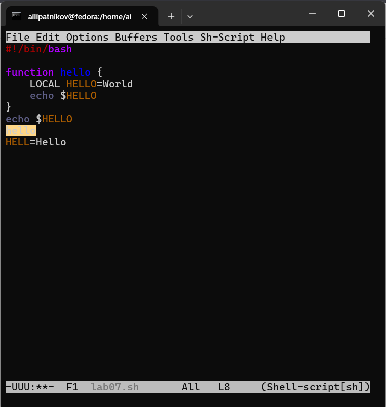

Выделение C-space и копирование M-w

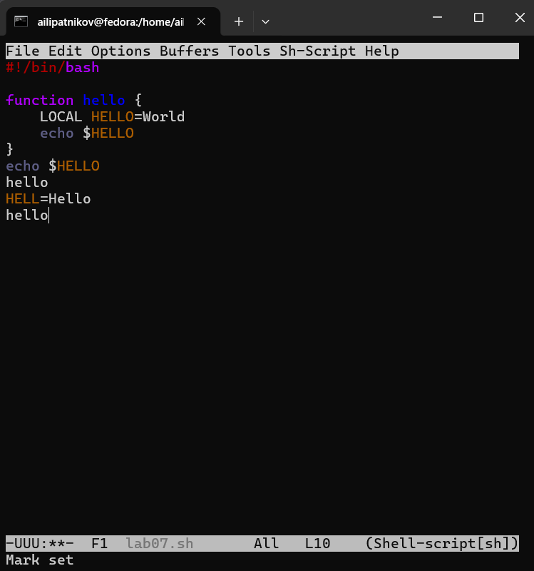

Вставка C-y

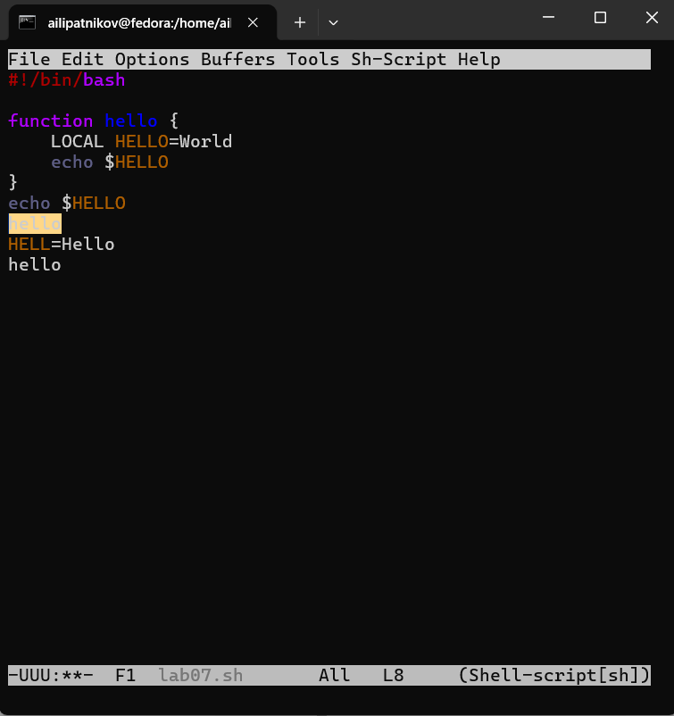

Вырезание C-w

- `C-space` — метка; `M-w` — копировать; `C-y` — вставить; `C-w` — вырезать

## Переход в конец буфера и отмена

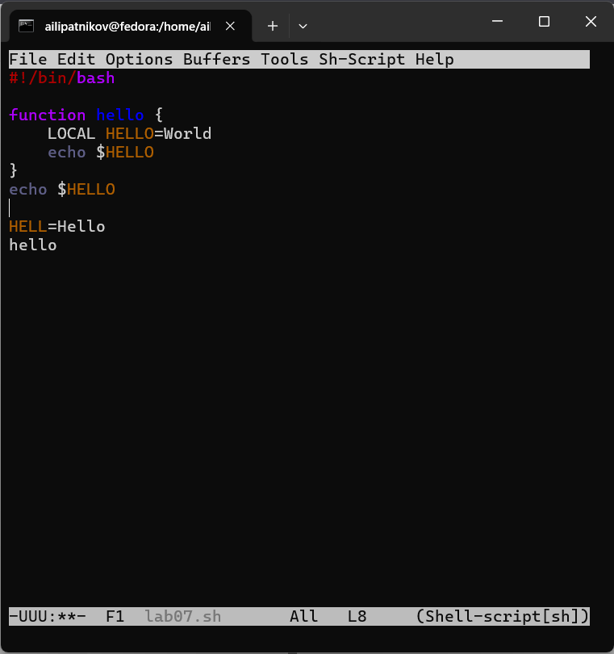

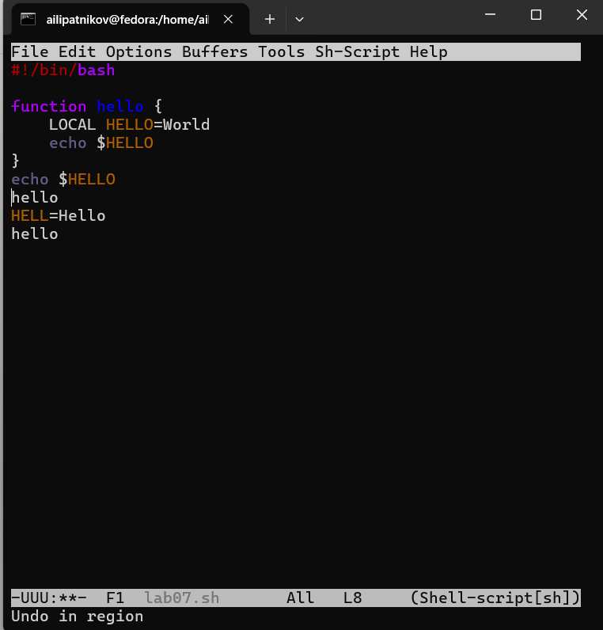

Отмена C-/

- `M->` — конец буфера; `C-/` — отмена

## Управление буферами

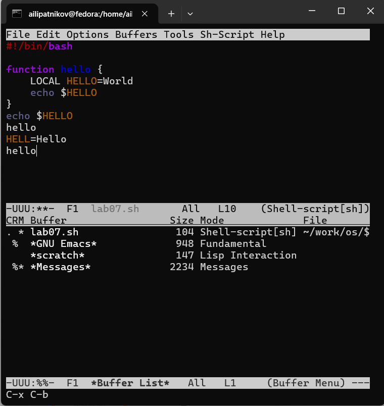

Список буферов C-x C-b

[figure not shown]

Переход C-x o

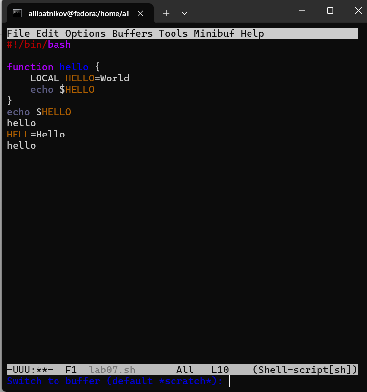

Переключение C-x b

- `C-x C-b` — список; `C-x o` — другое окно; `C-x b` — переключить буфер

## Разделение фрейма на 4 окна

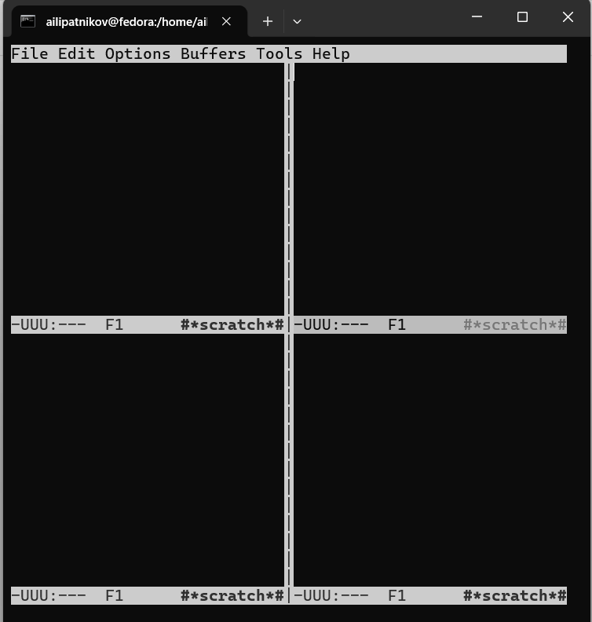

4 окна **scratch**

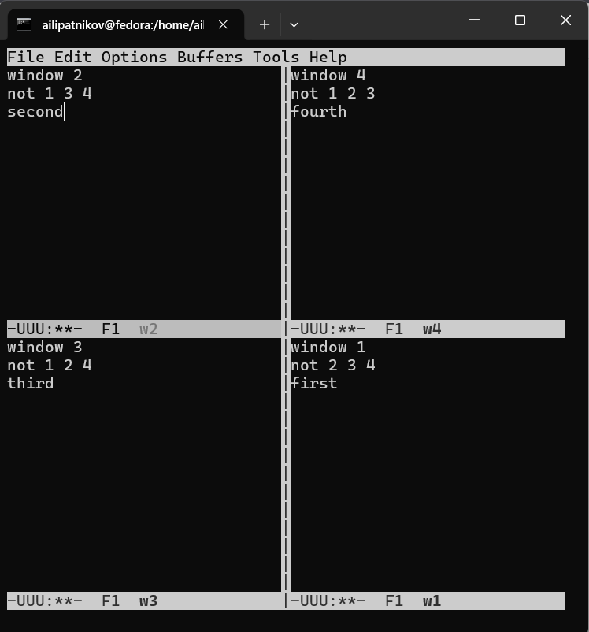

Текст в 4 окнах

- `C-x 3` — вертикально; `C-x 2` — горизонтально в каждом окне

## Режим поиска

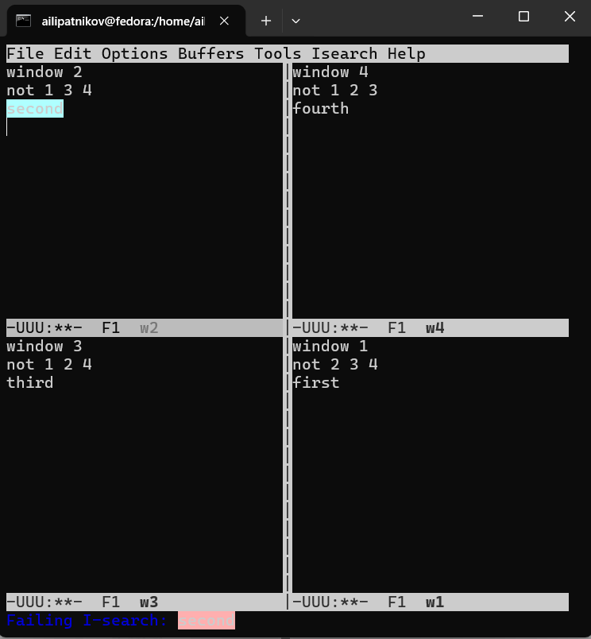

Поиск C-s

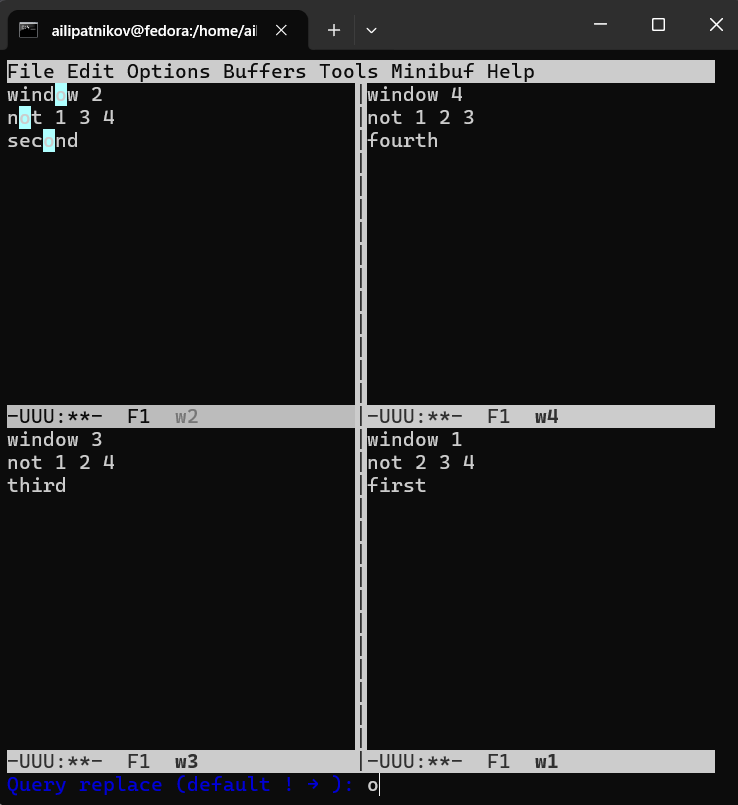

Поиск и замена M-%

- `C-s` — поиск вперёд; `M-%` — поиск и замена

## Occur и выход из поиска

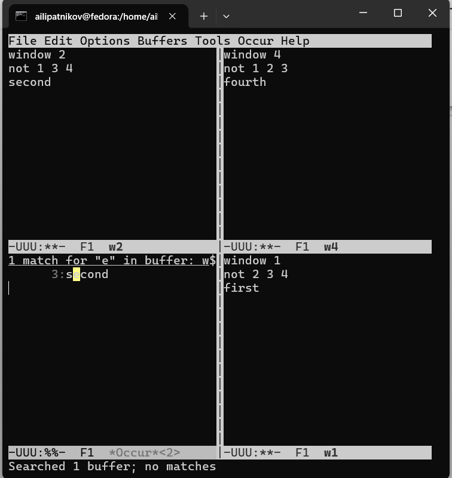

Occur M-s o

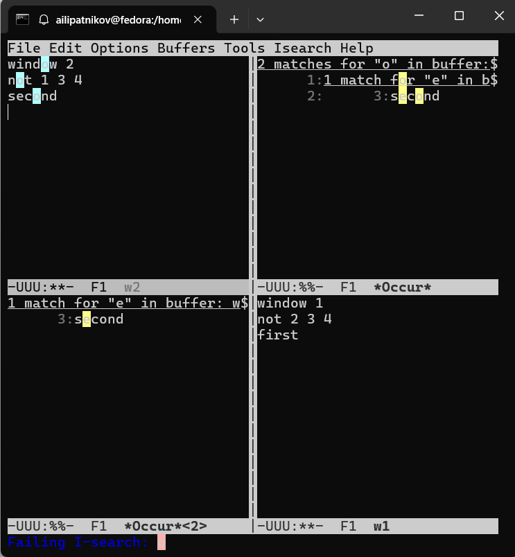

Выход C-g

- `M-s o` — Occur: список всех совпадений
- `C-g` — выход из поиска

# Результаты

## Полученные результаты

Таблица 1: Сводка результатов

| Действие | Команды Emacs |
| --- | --- |
| Создание файла | `C-x C-f`, `C-x C-s` |
| Навигация | `M-<`, `C-e`, `M->` |
| Работа с текстом | `C-space`, `M-w`, `C-y`, `C-w`, `C-/` |
| Буферы | `C-x C-b`, `C-x o`, `C-x b` |
| Окна | `C-x 3`, `C-x 2` |
| Поиск | `C-s`, `M-%`, `M-s o`, `C-g` |

# Заключение

## Главный вывод

Emacs — непрерывный редактор без разделения на режимы: ввод текста и команды доступны одновременно. Управление буферами и окнами даёт обзор нескольких файлов сразу, а режим Occur удобнее пошагового поиска. Навыки Emacs применимы и для правки текста, и для работы с кодом в Linux.